# Math 120 Lec 19

Your Name

25 October, 2019

## Samp Dists Continued

Last time, we constructed our first sampling dist!

Idea: we’re transitioning away from describing individual outcomes and towards descriptions of entire sample results.

Specifically, the sampling distro for xbar (aveage) with n=2 taken from the dice population.

Important upshot: now, we can something about how likely certain samples are!

Ex:If we roll two dice, what’s the probability that the AVERAGE xbar is 3.5? 6/36

This is boring, but this technique lets us compute probs for sample results!

We need sampling dists for more practical scenarios. They can be very complicated. But, we actually know a lot about them!

For PROPORTIONS, here are the imoprtant facts about the sampling dist:

1. Center. I.e., expected val. Concept: if we take a sample, what do we expect the sample proportion to be?

mu_phat = p

Sophie’s question: categorical?

Answer: proportions describe categories.

mu_phat = p

In english: we expect our sample proportion to be same as our population proportion! This is intuitive, but mathematically proveable!

Spread: for proportions, the “standard error” is:

SE(phat) = sqrt(p*(1-p)/n)

Ok, so we’ve got math for the center and spread.

But what about the shape? What does this distribution actully look like?

Amazing fact! As long as n is large, the sampling distribution always has a normal shape!!! No matter what the original population is!

Central Limit Theorem. Woooooah!

Reminder: Dice.

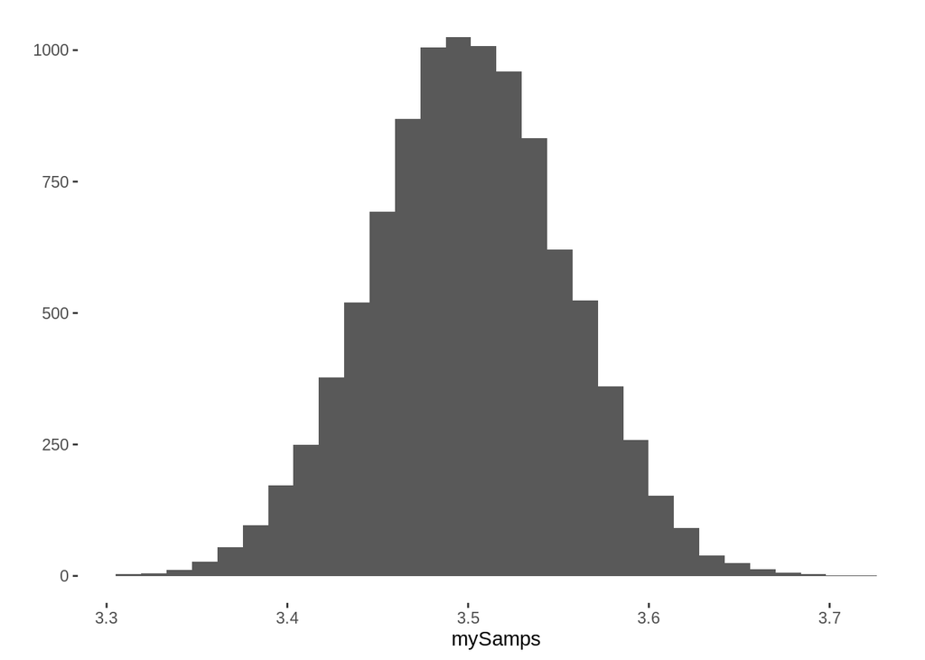

```r
replicate(10000,
          mean(sample(1:6, 1000, replace = TRUE))) -> mySamps

qplot(mySamps, geom="histogram", bins=30)
```

Recap: Thanks to the CLT, we know that our samp dists are always normal as long as n is large** (more on “large” later).

Practical example: Suppose 20% of DU students have black hair. If we take a sample of 100 DU students, what’s the probability that at least 15% of them have black hair?

Observations:

p = pop prop = .2. (NOte, we only know this because I made it up). phat = samp prop = .15

n = 100 (trust me, it’s big enough)

In math: P( phat >= .15 ) ???

We know the dist for phat.

mu = .20 SE = sqrt(.2*(1-.2)/100)=.04

```r
sqrt(.2*(1-.2)/100)
```

```
## [1] 0.04
```

We have a normal dist with mean .2 and stdev .04

All together:

```r
1-pnorm(.15, .2, .04)
```

```
## [1] 0.8943502
```

There’s an 89.4% chance of getting a SAMPLE RESULT like this! Cool!

What’s the chance that less than 30% of the students in teh sample have black hair?

mu = .2, se = .04, phat < .3

In math: P( phat < .3 ) ???

```r
pnorm(.3, .2, .04)
```

```
## [1] 0.9937903
```

About 65% of DU students have travelled internationally. If we take a sample of 150 students, what’s the prob that fewer than 50% of them have travelled internationally?

mu = .65

se = sqrt(.65*(1-.65)/150)

```r
sqrt(.65*(1-.65)/150)
```

```
## [1] 0.0389444
```

phat = .5

That’s all we need! pnorm!

```r
pnorm(.5, .65, .0389444)
```

```
## [1] 5.866353e-05
```

Example: About 17% of DU are international students. If we take a sample of 200 students, what’s the probability that at least 20% are international?

Metaquestion: Why are discussing this?

In the future, we’re going to be doing some statistical inference. Ie, we’ll make conclusions based on sample results. In order to do that, we need to know how likely or unlikely our sample results are. That’s what sampling dists are for.

Wait, this sampling dist must be complicated. There must be -many- possible samples of n=200 from DU students. How can we know about them all????

The hero of the story: the CLT. CLT assures us that, for large samples, the sample distro is very nearly normal. So, we -can- compute probabilities!!! Yay!!

This is also why the normal dist is sooooo important: it’s in all of our sample results!

So, we use pnrom but need the center and spread:

center = mu_phat = .17 (the pop proportion) SE(phat) = sqrt(.17*(1-.17)/200)

```r
sqrt(.17*(1-.17)/200)
```

```
## [1] 0.02656125
```

```r
1-pnorm(.2,.17,.02656125)  #1- for right area
```

```
## [1] 0.1293509
```

There’s about a 12.93% chance of obtaining a sample like this. I.e., not terribly unusual!!

Follow-up: what’s the probability that our sample of n=200 has fewer than 12% international students?

```r
pnorm(.12,.17, .02656125)
```

```
## [1] 0.02988805
```

There’s about a 2.9% chance. Human feelings: this is an unusual sample!! What’s up???

At the columbus zoo, 52% of all animals are mammals. If we take a sample of 50 randomly selected animals at the zoo, what’s the probability that between 40% and 45% of them are mammals?

n is large, thus normal dist

center = .52

spread = sqrt(.52*(1-.52)/50)

```r
sqrt(.52*(1-.52)/50)
```

```
## [1] 0.07065409
```

```r
pnorm(.45,.52, .0707)-pnorm(.40,.52, .0707)
```

```
## [1] 0.1162441
```

As we’ll see, a common criteria for “unusual” is 05%. This lines up with the 68-95-99.7 rule: if an observation is more than 2 std devs away from the mean, we often consider it unusual.

### “Large” samples

How large is large enough?

Recall from your lab that even n=2 or n=10 are rather normal-loooking. To ensure high-precision work, we have standards for how big n needs to be.

It depends on context!! What data? What statistic?

Here, we’ve been discussion CATEGORICAL variables. Your book calls is the “success/failure” criterion. Our sample needs to have at least 10 success AND 10 failures.

In the international example: sample must have at least 10 international students AND 10 domestic students.

To check mathematically: need BOTH:

- n*phat >= 10
- n*(1-phat) >=10

Think of the zoo example: p=.52, n=50. Were we justified in using a normal dist?

Check: n*p = .52*50

```r
.52*50
```

```
## [1] 26
```

So far so good! Still need:

```r
(1-.52)*50
```

```
## [1] 24
```

Also bigger than 10! We ARE justified in using a normal dist for phat.

Suppose 99% of people are honest, we plan to administer a lie detector test to find the dishonest folks. If we take sample of size n=150, is that enough to ensure our samples results follow a normal distribution?

```r
.99*150
```

```
## [1] 148.5
```

```r
(1-.99)*150
```

```
## [1] 1.5
```

Oh no! We didn’t satisfy both requirements! Can’t use normal dist here, n isn’t big enough!

Nothing we can do, except take a larger sample. We can’t make successful inference from this population.